# eBird Sampling Effort Summaries ***** DRAFT *****

N.M. Tarr

12 February 2021

# Purpose

This notebook summarizes eBird sampling (effort) within North Carolina for the past 5 years. Sampling data can be downloaded from the eBird website and queried with eBird’s R package named “auk”. The script named “filter_eBird_sampling.R”, which is saved in the NCBA github repo, performs the filtering that supports this notebook.

The records available from the sampling data set are for individual, unique checklists and several attributes are included for each. This notebook summarizes the available attribute values to learn as much as possible about the modern eBird effort to date within North Carolina. The available checklist attributes are:

- checklist_id
- last_edited_date
- county
- county_code
- iba_code
- bcr_code
- usfws_code
- atlas_block
- locality
- locality_id
- locality_type
- latitude
- longitude
- observation_date
- time_observations_started
- observer_id
- sampling_event_identifier
- protocol_type
- protocol_code
- project_code
- duration_minutes
- effort_distance_km
- effort_area_ha
- number_observers
- all_species_reported
- group_identifier
- trip_comments

# General

- There are currently 474,094 checklists from North Carolina in eBird.

# Week

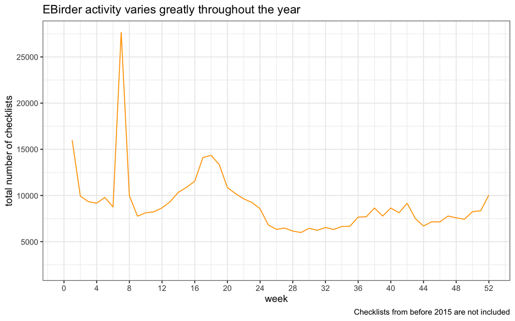

# Locality

- Many checklists are revisits to previously surveyed locations. The ratio of locations that were visited once to the total number of checklists is 0.12.
- Most locations have only been sampled once. However, some locations have been visited an enormous number of times.

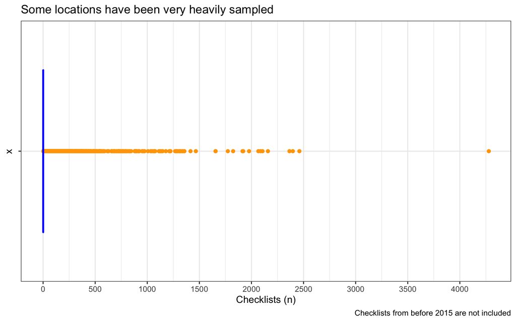

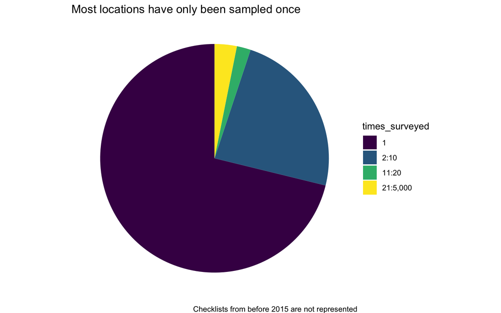

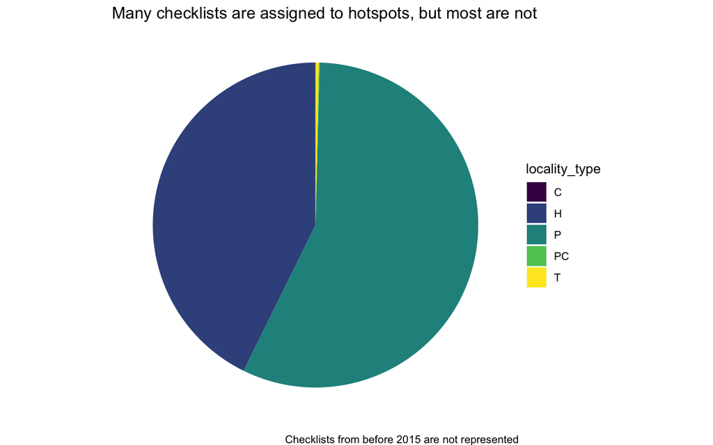

Number of checklists per locality type

| locality_type | count |
| --- | --- |
| C | 2 |
| H | 202465 |
| P | 269667 |
| PC | 420 |
| T | 1540 |

## Most Visited Locations Table

Locations visited 100 or more times.

| locality | locality_id | count |
| --- | --- | --- |
| Beaver Lake Bird Sanctuary | L166279 | 4278 |
| Mid Pines Rd. | L1263899 | 2460 |
| 40 Flack Valley Road | L2579291 | 2397 |
| Sandy Creek Park | L971411 | 2365 |
| Neighbarger-Colvin home | L660029 | 2158 |
| Lake Junaluska | L248876 | 2106 |
| Mason Farm Biological Reserve | L331344 | 2087 |
| Yates Mill County Park | L486971 | 2066 |
| Jackson Park | L207852 | 1977 |
| Lake Crabtree County Park | L303621 | 1921 |
| Bodie Island Lighthouse & Pond | L365371 | 1914 |
| Waves soundfront | L3129074 | 1824 |
| Severin Street | L1941647 | 1773 |
| Cornelius rental home | L5653317 | 1656 |
| My House | L306395 | 1655 |
| Prairie Ridge Ecostation for Wildlife Learning | L579187 | 1466 |
| Pea Island NWR–North Pond Wildlife Trail | L1663502 | 1415 |
| Pea Island NWR–North Pond | L130800 | 1356 |
| 185 Knoll Rd. Southern pines, nc 28387 | L3772996 | 1343 |
| Howerton Rd. | L4160235 | 1333 |
| Historic Bethabara Park–Lower Trails | L358727 | 1318 |
| Beaver Marsh | L855859 | 1314 |
| Brumley Nature Preserve–North | L7984234 | 1305 |
| Neuse River Trail–Abbotts Creek | L1597517 | 1291 |
| Ecusta Pond (private) | L1804745 | 1282 |
| Lake Betz | L1471163 | 1282 |
| Lake Crabtree Nature Trail–Southport Entrance | L2205740 | 1275 |
| home | L1957878 | 1267 |
| Archie Elledge Treatment Plant (restricted access) | L386755 | 1223 |
| Hooper Lane | L870227 | 1218 |

[output cut: 703 more lines]

# Spatial Distribution

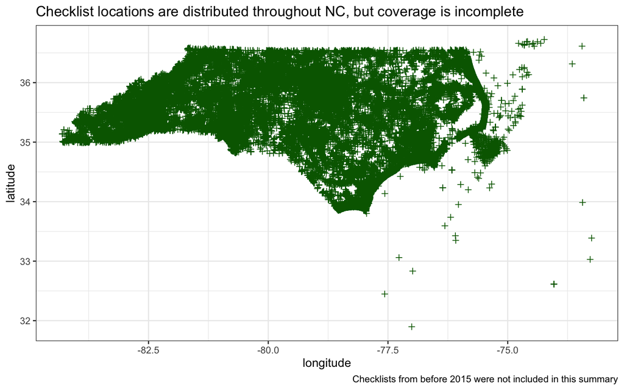

## Checklists per County

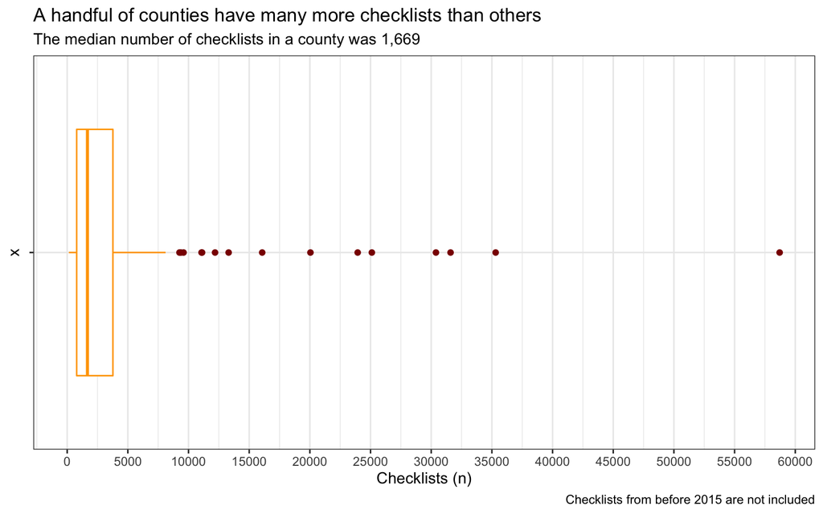

Between 141 and 58,712 checklists are available for counties in North Carolina, and the median number of checklists is 1,669.

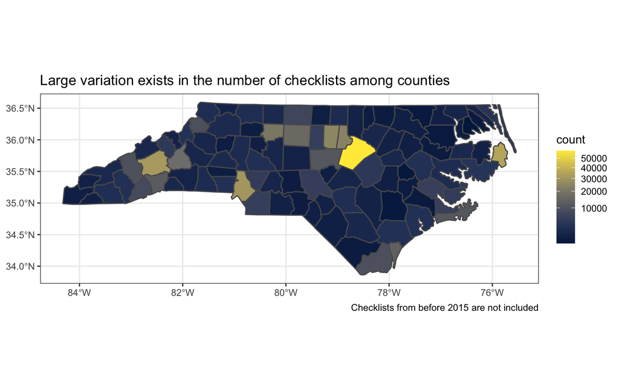

### Top 10 Counties

Top 10 Counties

| county | count |
| --- | --- |
| Wake | 58712 |
| Dare | 35310 |
| Buncombe | 31594 |
| Mecklenburg | 30389 |
| Orange | 25108 |
| Durham | 23940 |
| Forsyth | 20047 |
| Guilford | 16071 |
| New Hanover | 13305 |
| Henderson | 12187 |

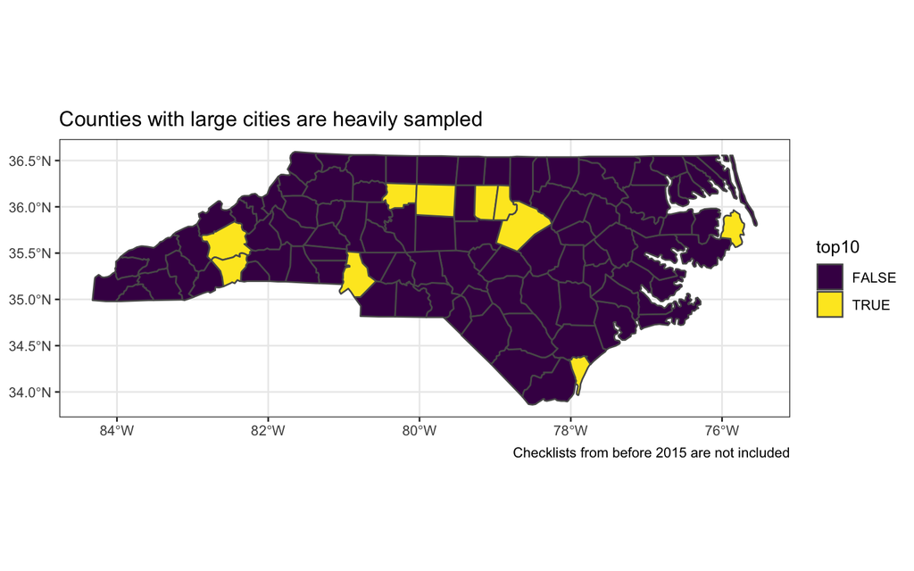

### Bottom 10 Counties

Bottom 10

| county | count |
| --- | --- |
| Perquimans | 141 |
| Greene | 212 |
| Duplin | 251 |
| Bertie | 309 |
| Northampton | 317 |
| Pasquotank | 332 |
| Jones | 378 |
| Columbus | 408 |
| Martin | 410 |
| Warren | 466 |

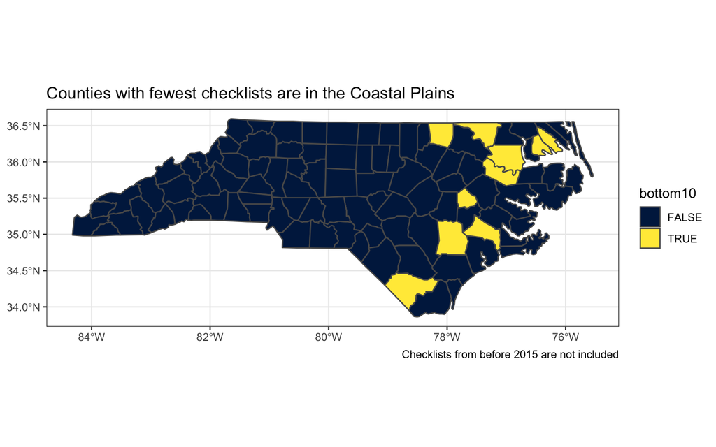

### Checklists per County Table

Note, the assignment of checklists to counties was performed by eBird and it is possible that errors exist due to traveling counts that cross county lines and errors in the recorded locations of checklists.

| county | count |
| --- | --- |
| Alamance | 5358 |
| Alexander | 561 |
| Alleghany | 1018 |
| Anson | 960 |
| Ashe | 2499 |
| Avery | 3040 |
| Beaufort | 2380 |
| Bertie | 309 |
| Bladen | 1695 |
| Brunswick | 9384 |
| Buncombe | 31594 |
| Burke | 1484 |
| Cabarrus | 4914 |
| Caldwell | 1457 |
| Camden | 1297 |
| Carteret | 11074 |
| Caswell | 614 |
| Catawba | 1920 |
| Chatham | 11117 |
| Cherokee | 634 |
| Chowan | 599 |
| Clay | 830 |
| Cleveland | 2254 |
| Columbus | 408 |
| Craven | 5644 |
| Cumberland | 2586 |
| Currituck | 3589 |
| Dare | 35310 |
| Davidson | 1423 |
| Davie | 774 |

[output cut: 70 more lines]

## Checklists per Atlas Block

Forthcoming

# Observers

## All observers

Most eBirders have only submitted a handful of checklists. The median number of checklists submitted is only 2, and observers who have submitted more than 6 are in the top quartile for number of submissions.

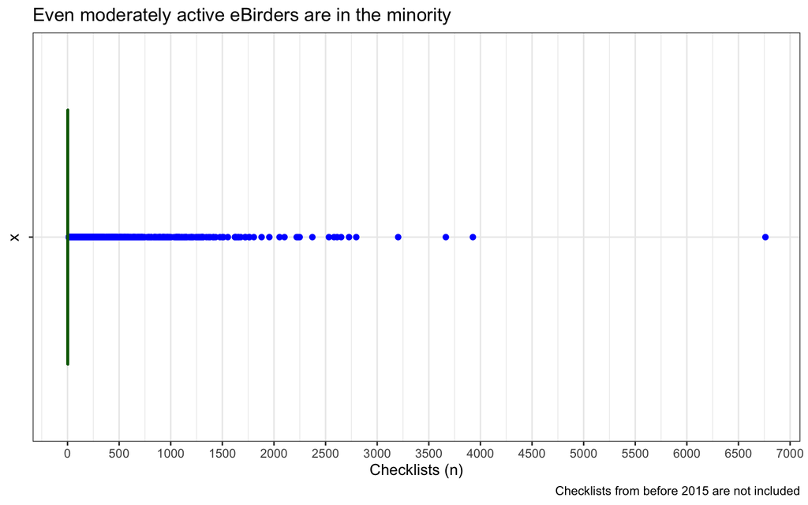

## Core observers

It is informative to look more closely at a subset of active observers in order to better characterize observers who may participate in the atlas. Here, I exclude the extreme outliers and people with fewer than some arbitrarily “small” number of submissions (20).

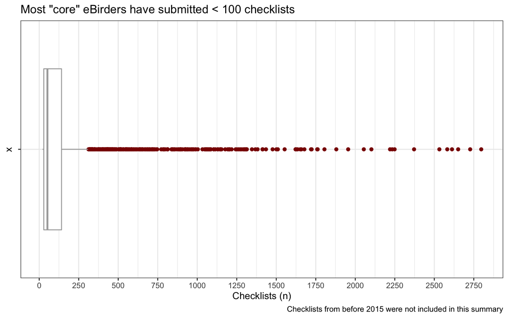

# Protocol

| Protocol Type | Checklists (n) |
| --- | --- |
| Area | 441 |
| Banding | 26 |
| CWC Area Search | 1 |
| eBird Pelagic Protocol | 118 |
| Historical | 2664 |
| Incidental | 2101 |
| International Shorebird Survey (ISS) | 361 |
| Nocturnal Flight Call Count | 35 |
| Random | 338 |
| Rusty Blackbird Spring Migration Blitz | 75 |
| Stationary | 207139 |
| Trail Tracker | 3 |
| Traveling | 260791 |
| Tricolored Blackbird Winter Survey | 1 |

# Project

| Project | Checklists (n) |
| --- | --- |
| EBIRD | 455684 |
| EBIRD_AK | 58 |
| EBIRD_ATL_MD_DC | 88 |
| EBIRD_ATL_ME | 5 |
| EBIRD_ATL_NY | 96 |
| EBIRD_ATL_NZ | 2 |
| EBIRD_ATL_VA | 221 |
| EBIRD_ATL_WI | 42 |
| EBIRD_AU | 35 |
| EBIRD_BCN | 124 |
| EBIRD_BRA | 4 |
| EBIRD_CAMERICA | 173 |
| EBIRD_CAN | 258 |
| EBIRD_CB | 41 |
| EBIRD_CBW | 1 |
| EBIRD_CL | 11 |
| EBIRD_GBBC | 15480 |
| EBIRD_IND | 16 |
| EBIRD_KIOSK | 8 |
| EBIRD_MA | 87 |
| EBIRD_ME | 299 |
| EBIRD_MEX | 39 |
| EBIRD_MO | 3 |
| EBIRD_MYS | 8 |
| EBIRD_NH | 17 |
| EBIRD_NJ | 122 |
| EBIRD_NZ | 2 |
| EBIRD_PA | 53 |
| EBIRD_PNW | 101 |
| EBIRD_PR | 3 |
| EBIRD_QC | 166 |
| EBIRD_TWN | 11 |
| EBIRD_TX | 77 |
| EBIRD_VA | 655 |
| EBIRD_VINS | 28 |
| EBIRD_WI | 76 |

# Start Time

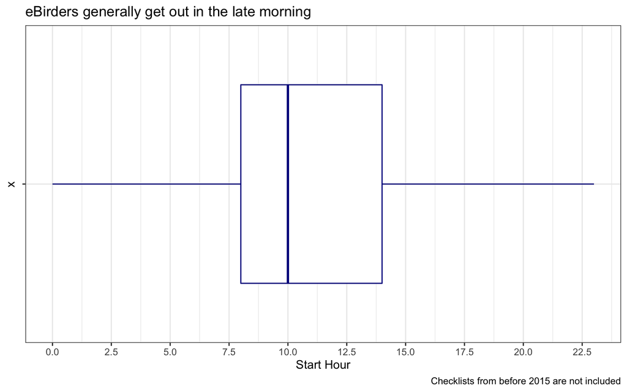

# Duration

- The durations of most checklists are less than one day (1,440 minutes), but 25 checklists carried on longer than a day and 552 checklists lasted between 12 and 24 hours.
- I omitted checklists longer than 12 hours for the summaries in this section.

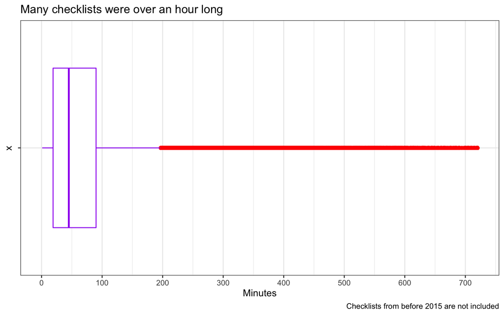

```
##    Min. 1st Qu.  Median    Mean 3rd Qu.    Max.
##    1.00   19.00   45.00   67.66   90.00  720.00
```

# Distance

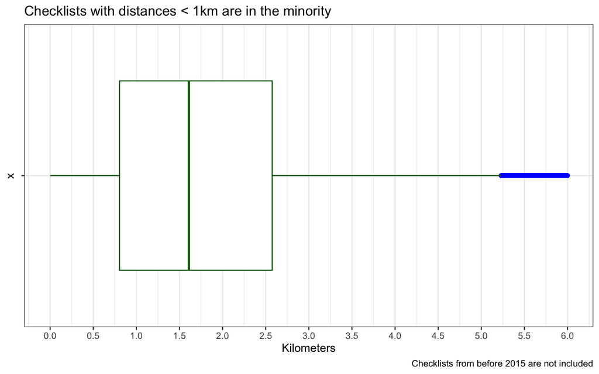

```
##    Min. 1st Qu.  Median    Mean 3rd Qu.    Max.
##   0.000   0.805   1.609   1.798   2.575   5.999
```

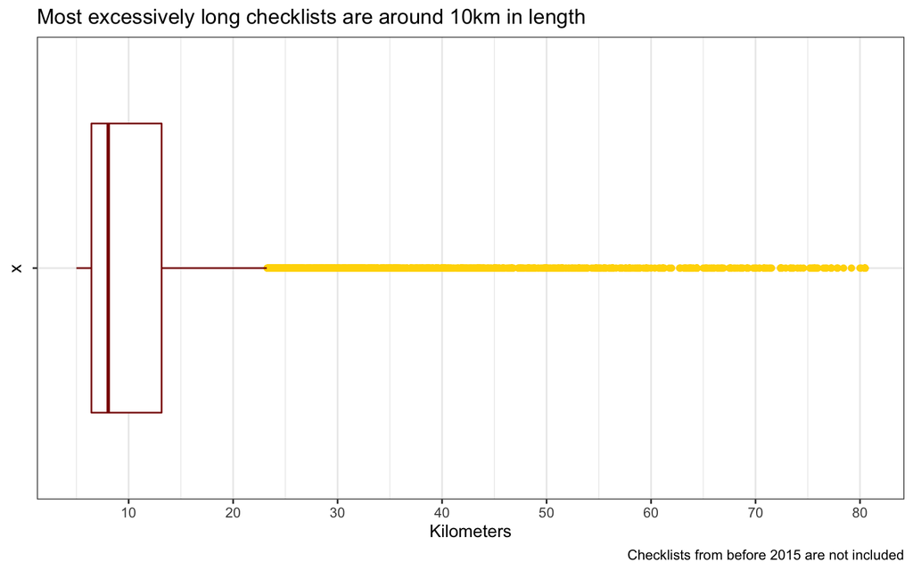

```
##    Min. 1st Qu.  Median    Mean 3rd Qu.    Max.
##   5.001   6.437   8.047  12.406  13.156  80.467
```

# Runtime

1.249613 mins